# Stock Market Trading Strategy Research -- Hire an AI to make you money!

## 1. Introduction

**Stock market** is famous for its unpredictable characteristic, and the kinds of **trading strategies** are so massive that one can hardly learn all of them in a short period (Heaton et al., 2017).

The two pain points of trading in this market are **1)** how to predict further variation of the stock; **2)** how to perform in terms of the corresponding variation. The stock price prediction is very hard due to the uncertainty of the stock itself, with many outer issues affecting the market (Heaton et al., 2017; Deng et al., 2016; Kimoto et al., 1990; Schöneburg & Eberhard, 1990). As for actions, methods by tradional financial statistics roughly calculate the variation of the portfolio and distribute the investment well to minimize that, which does not certainy results to a high return at last (Jondeau et al., 2006).

Fortunately, **Deep Learning** methods such as **Convolution Neural Network**, **Recurrent Neural Network** or even just **Deep Fully Connected Network**, are very useful for prediction, especially the time-series data, which is correlated among stocks. What is more fortunate, **Reinforcement** (which can be showed as **Recurrent**) thoughts are helpful to represent the long-time trading. On the other words, action to take each trading day can be acquired by these minds (Fischer & Krauss, 2018; Heaton et al., 2017; Deng et al., 2016; Choi et al., 2009).

To take the research, the essay hereby utilize two main different trading algorithm, **Deep Direct Reinforcement Network**and **Deep Q Network** (Mnih et al., 2015; Heaton et al., 2017), while each main algorithm has differing forms to dive further, so as to acquire outcomes, as excellent as possible and as stable as possible. All evaluations and sensitivity-analysis in need follow the corresponding algorithms.

#### *Abbreviation*

- *DL: Deep Learning*
- *DNN: Deep Neural Network*
- *CNN: Convolution Neural Network*
- *RNN: Recurrent Neural Network*
- *GRU: Gated Recurrent Units*
- *LSTM: Long Short-Term Memory*
- *DFCN: Deep Fully Connected Network*
- *DRN: Direct Reinforcement Network*
- *DDRN: Deep Direct Reinforcement Network*
- *DQN: Deep Q Network*

[figure not shown]

```python
import tensorflow as tf
import keras
from keras.models import Sequential
from keras.models import load_model
from keras.layers import Dense
from keras.optimizers import Adam

import matplotlib.pyplot as plt

import pandas as pd
import numpy as np
import math
import datetime
import pickle
import random

import warnings
import logging
import os

warnings.filterwarnings("ignore") # ignore many useless warnings
tf.logging.set_verbosity(tf.logging.FATAL)
if type(tf.contrib) != type(tf): tf.contrib._warning = None
```

## 2. Data Exploration

### 2.1 Data Collection

The essay utilize quandl API to acquire all the stocks among S&P100, like GOOG or APPL, with trading dates from 2008-01-01 to 2018-01-01. The codes below are commented and the data has already been saved for the sake of time. The S&P100 lists is acquired from https://en.wikipedia.org/wiki/S%26P_100.

```python
# import quandl

# quandl.ApiConfig.api_key = "Uyrfi6nMmG1fA42aroAH"

# with open("data/SP100.txt") as file:
#     SP100 = [i.strip() for i in file.readlines()]

# finance_data = quandl.get_table('WIKI/PRICES', ticker = SP100,
#                         qopts = {'columns': ['ticker', 'date', 'close', 'adj_close'] },
#                         date = {'gte': '2008-01-01', 'lte': '2018-01-01' },
#                         paginate=True)

# finance_data = finance_data.pivot_table(index="date", columns="ticker") # get pivot table

# with open('data/finance_data', 'wb') as file:
#     pickle.dump(finance_data, file)
```

### 2.2 Data Preprocess

These stocks do not have their prices in every trading day. So that the essay only takes the stock with valid dates more than 2500 days, for which the essay fills the missing values by backward method. The essay makes the log-return from the price of each trading day, for further research. Because the return of a stock is more valuable than the price itself, which is not scaled and not informative in the return part.

```python
with open('finance_data', 'rb') as file:
    finance_data = pickle.load(file)

ATTR = "close"

price = finance_data[ATTR].dropna(axis=1, thresh=2500).fillna(axis=0, method="backfill", limit=1)
price_week = [i for _, i in price.groupby(pd.Grouper(freq='W'))] # weekly group
logreturn = np.log(price).diff().dropna(axis=0) # log return]
ticks = logreturn.columns

print("Data includes %d days and %d stocks in total."%(price.shape),
      "----------------STATISTICS-------------------",
      "NAN data: %d"%price.isna().sum().sum(),
      "Fully week: %.2f%%"%(sum([len(i) == 5 for i in price_week]) / len(price_week) * 100),
      sep="\n")
```

```
Data includes 2518 days and 87 stocks in total.
----------------STATISTICS-------------------
NAN data: 0
Fully week: 82.76%
```

For the sake of efficiency, the algorithm in the essay will all use batch methods to speed up and add more randomness by indexing the data out from different possible dates. The codes are showed below, where the num_batches decide how many batches to use in each epoch.

```python
def build_batch(data, step, lag, num_batches):
    indices = np.arange(lag , len(data) - step + 1) # should be steps ahead of the last one
    np.random.shuffle(indices) # shuffle the id rather than data in order to save memory
    batches = np.zeros([num_batches, lag + step, num_stocks])

    for i in range(num_batches):
        index = indices[i]
        batch = data[(index - lag):(index + step)] # if index=2, lag=2, step=6: data[0, 1, 2, .., 7]
        batches[i] = batch

    return batches
```

### 2.3 Data Visualization

The stock prices and corresponding log returns are showed below for more understanding of the data.

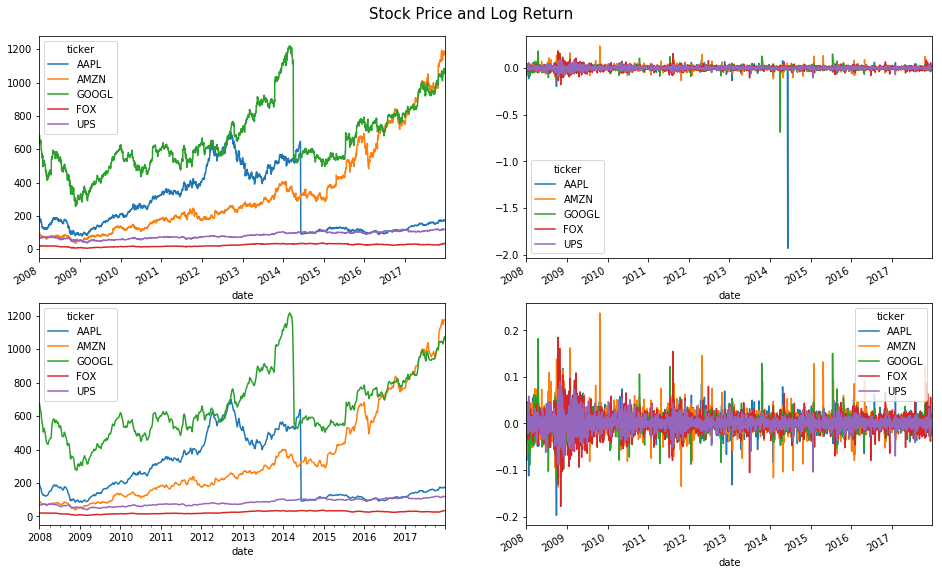

```python
present = ['AAPL', 'AMZN', 'GOOGL', 'FOX', 'UPS']
fig, axes = plt.subplots(nrows=2, ncols=2, figsize=(16, 10))
price[present].plot(ax=axes[0, 0]);
price[present].groupby(pd.Grouper(freq='W')).mean().plot(ax=axes[1, 0])
logreturn[present].plot(ax=axes[0, 1]);
pd.DataFrame(np.where(np.abs(logreturn[present]) > 0.5, 0, logreturn[present]), columns=logreturn[present].columns, index=logreturn[present].index).plot(ax=axes[1,1]);
fig.suptitle("Stock Price and Log Return", y=0.92, fontsize=15);
```

> The graph hereby presents the five stocks prices and their log returns. The second row of graphs are the smoothing and special cases removing version.

> The Apple and Google stock price have sharp declines around 2014, because they undertook the stock redistribution resulting price falling dramatically. To deal with that, the essay will thus use this time to split training and testing data if we choose these stocks.

## 3. Deep Direct Reinforcement Network (DDRN)

### 3.1 Direct Reinforcement Network (DRN)

Deep Neural Network is able to provide a brilliant classifier or predict further possible outcome. Reinforcement Network otherwise can include the state so far, the action it may produce and the state plus the action will result to the next state as well as the reward for this action. The essay hereby combines the two into Deep Direct Reinforcement Network (DDRN), where Deep Neural Network works for prediction by the stock price and Reinforcement Network makes the action and stores the states and rewards for further iteration. The graph is showed below:

[figure not shown]

**Action** here is to adjust the investment distribution according to the output of the Neural Network, i.e. if the output is x, y, z and then the agent will distribute all assets (including capital and profits) with regard to x:y:z.

**Reward** is the profits we gain, and **state** is the stock log return during the last few days.

It is also noted that this DRL cell is like the squential situation, which also takes the input step by step and convey and iterate the state sequentially. Therefore, the essay implemented the DRL by a squential structure, with all states, actions and rewards updated with trading days going by. The codes are showed below:

```python
def reinforcement(data, state, lag, cost, step, flag, testing=False):
    flag = flag.lower()
    if testing:
        num_stocks = data.shape[2]
        num_batches = data.shape[0]
    else:
        num_stocks = data.shape[2].value
        num_batches = data.shape[0].value

    actions = [np.reshape(np.ones(num_stocks) / num_stocks, [1, num_stocks])]# for calculation only, remove at last
    states = [state] # initial investment

    for i in range(step - 1):
        if flag == "cnn":
            output = convolution(data[:, i:lag+i+1, :], testing=testing)
        else:
            output = recurrent(data[:, i:lag+i+1, :], flag=flag, testing=testing)

        actions.append(dense(output, actions[-1], testing=testing)) # lag days and today (lagn, ..., lag2, lag1, 0)
        rewards = states[-1] * actions[-1] * tf.exp(data[:, i+lag+1, :]) - cost * tf.abs(actions[-1] - actions[-2])
        states.append(tf.reshape(tf.reduce_sum(rewards, axis=1), [num_batches, 1]))

    return tf.convert_to_tensor(actions[1:], tf.float64), states
```

### 3.2 Convolution Neural Network (CNN)

For DNN, the first kind of network the essay uses is Convolution Neural Network, which is famous for its fast and direct process towards matrix. Similarly, for financial data, if we have many stocks and each stock has many trading days' prices, it is naturally a good matrix data well designed for CNN (Krizhevsky et al., 2012).

The essay hereby produces the values with the length equals to the number of stocks the essay use for trading or making portfolio, to monitor the return of each stock in the future. The configurations and codes are showed below:

| Name | Size |
| --- | --- |
| Input | Dates * Stocks |
| Conv1 | 5 *5* 12 |
| Pool1 | 2 * 2 |
| Conv2 | 5 *5* 24 |
| Pool2 | 2 * 2 |
| Dense | 1000 |
| Dense | Stocks |

```python
def convolution(data, testing=False):
    if testing:
        num_stocks = data.shape[2]
        num_dates = data.shape[1]
    else:
        num_stocks = data.shape[2].value
        num_dates = data.shape[1].value

    with tf.variable_scope('cnn', reuse=tf.AUTO_REUSE):
        inputs = tf.reshape(data, [-1, num_dates, num_stocks, 1])

        # convolutional layer 1
        conv1 = tf.layers.conv2d(inputs=inputs, filters=12, kernel_size=[5, 5], strides=[1, 1], padding="same", activation=tf.nn.relu)
        pool1 = tf.layers.max_pooling2d(inputs=conv1, pool_size=[2, 2], strides=2, padding='SAME') # padding to make use of edges
        dropout1 = tf.layers.dropout(inputs=pool1, rate=0.3, training=True)

        # convlutional layer 2
        conv2 = tf.layers.conv2d(inputs=dropout1, filters=24, kernel_size=[5, 5], strides=[1, 1], padding="same", activation=tf.nn.relu)
        pool2 = tf.layers.max_pooling2d(inputs=conv2, pool_size=[2, 2], strides=2, padding='SAME')
        dropout2 = tf.layers.dropout(inputs=pool2, rate=0.3, training=True)
                                            # 10 -> 5 -> 3
        p2_flat = tf.reshape(dropout2, [-1, math.ceil(math.ceil(num_dates / 2) / 2) * \
                                            math.ceil(math.ceil(num_stocks / 2) / 2) * \
                                            24])

        # dense layer
        h1 = tf.layers.dense(inputs=p2_flat, units=1000, activation=tf.nn.relu)
        dropout3 = tf.layers.dropout(inputs=h1, rate=0.4, training=True)

        # output layer
        outputs = tf.layers.dense(inputs=dropout3, units=num_stocks, activation=None)

    return outputs
```

### 3.3 Recurrent Neural Network (RNN)

For DNN as well, the second kind of network the essay uses is Recurrent Neural Network (Chung et al., 2014; Hochreiter et al., 1997), which is famous for its ability towards the sequential data, especially time series data, which is also an important nature of financial data. The essay chooses the two cells that are popular when confronting the highly correlated data, such as stock return among the S&P100:

- **Gated Recurrent Units (GRU)**
- **Long Short-Term Memory (LSTM)**

The essay hereby produces the values with the length equals to the number of stocks the essay use for trading or making portfolio, also to monitor the return of each stock in the future. The codes are showed below:

```python
def recurrent(data, flag, testing=False):
    flag = flag.lower()

    if testing:
        num_dates = data.shape[1]
        num_stocks = data.shape[2]
    else:
        num_dates = data.shape[1].value
        num_stocks = data.shape[2].value

    with tf.variable_scope('rnn', reuse=tf.AUTO_REUSE): # choose different flag
        if flag == "lstm":
            cell = tf.contrib.rnn.BasicLSTMCell(num_stocks * 4)
            rnn, _ = tf.contrib.rnn.static_rnn(cell, tf.unstack(data, num_dates, axis=1), dtype=tf.float64)
        elif flag == "gru":
            cell = tf.contrib.rnn.GRUCell(num_stocks * 4)
            rnn, _ = tf.contrib.rnn.static_rnn(cell, tf.unstack(data, num_dates, axis=1), dtype=tf.float64)
        else:
            print("No this cell. The function only includes: LSTM, GRU.")

        h = tf.layers.dense(inputs=rnn[-1], units=256, activation=None)
        dropout = tf.layers.dropout(inputs=h, rate=0.4, training=True)

        outputs = tf.layers.dense(inputs=dropout, units=num_stocks, activation=None)

    return outputs
```

### 3.4 Deep Fully Connected Network (DFCN)

[figure not shown]

```python
def dense(data, action, testing=False):
    if testing:
        num_stocks = data.shape[1]
    else:
        num_stocks = data.shape[1].value

    with tf.variable_scope('dense', reuse=tf.AUTO_REUSE):
        w1 = tf.get_variable("weightsforcnn", shape=[num_stocks, num_stocks * 2], dtype=tf.float64, initializer=tf.random_normal_initializer())
        b1 = tf.get_variable("biasforcnn", shape=[num_stocks * 2], dtype=tf.float64, initializer=tf.constant_initializer(0.0))
        wp = tf.get_variable("weightsforpolicy", shape=[num_stocks, num_stocks * 2], dtype=tf.float64, initializer=tf.random_normal_initializer())
        output1 = tf.sigmoid(tf.matmul(data, w1) + tf.matmul(action, wp) + b1) # combine the previous portfolio

        w2 = tf.get_variable("weights2", shape=[num_stocks * 2, num_stocks], dtype=tf.float64, initializer=tf.random_normal_initializer())
        b2 = tf.get_variable("bias2", shape=[num_stocks], dtype=tf.float64, initializer=tf.constant_initializer(0.0))
        output2 = tf.nn.softmax(tf.add(tf.matmul(output1, w2), b2))

        output2 = tf.nn.softmax(data)

        return output2
```

### 3.5 Agent Deployment

The essay hereby makes the whole agent process. We choose the training data and testing data from the original data, the hyper parameters, and the rule of our agent, e.g. how many days before today to concern, how many days to hire, the transcation cost.

```python
def runAgent(ax, label="", show_train=True):
    print(flag+label, "method works now...")
    tf.reset_default_graph()

    data = tf.placeholder(tf.float64, shape = [num_batches_train, lag + step, num_stocks])

    actions, states = reinforcement(data, tf.constant(np.full([num_batches_train, 1], 10000.0)), lag, cost, step, flag)
    optimizer = tf.train.AdamOptimizer(learning_rate=learning_rate).minimize(-tf.reduce_mean(states[-1]))

    test_batches = build_batch(test_data, step, lag, num_batches_test)
    actions_pred, states_pred = reinforcement(test_batches, tf.constant(np.full([num_batches_test, 1], 10000.0)),
                                   lag, cost, step, flag, testing=True)

    trains = [initial_invest]
    preds = [initial_invest]
    with tf.Session() as sess:
        sess.run(tf.global_variables_initializer())
        sess.run(tf.local_variables_initializer())
        for epoch in range(1, epochs+1):
            train_batches = build_batch(train_data, step, lag, num_batches_train)
            _, states_ = sess.run([optimizer, states], feed_dict = {data: train_batches})

            train = sum(states_[-1]) / num_batches_train # train
            pred = sum(states_pred[-1].eval()) / num_batches_test # test

            trains.append(train)
            preds.append(pred)

            if epoch%50 == 0 or epoch == 1:
                print("No.%d Epoch: Train: %0.2f ; Test: %0.2f"%(epoch, train, pred))
        actionss = actions_pred.eval()

    if show_train:
        ax.plot(trains, label='Train'+label)
    ax.plot(preds, label='Test'+label)
    ax.set_title(flag, fontsize=12)
    ax.legend()
    return actionss;
```

#### CNN vs GRU vs LSTM

The essay hereby tests the outcome differences among CNN, GRU and LSTM. I set the initial investment at 10 thousand, and the cost is 1 for each stock change.

```
CNN method works now...
No.1 Epoch: Train: 10611.43 ; Test: 11656.62
No.50 Epoch: Train: 11315.91 ; Test: 11535.27
No.100 Epoch: Train: 11383.05 ; Test: 11535.27
GRU method works now...
No.1 Epoch: Train: 10579.05 ; Test: 11727.11
No.50 Epoch: Train: 11388.98 ; Test: 11540.09
No.100 Epoch: Train: 11385.37 ; Test: 11539.80
LSTM method works now...
No.1 Epoch: Train: 10590.18 ; Test: 11718.86
No.50 Epoch: Train: 11380.53 ; Test: 11495.77
No.100 Epoch: Train: 11411.93 ; Test: 11495.70
```

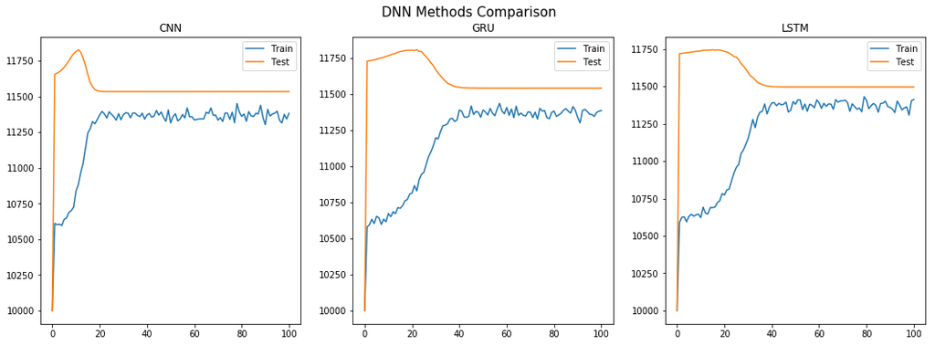

```python
if __name__ == "__main__":
    values = logreturn[['ORCL', 'AMZN', 'MSFT', 'IBM', 'NVDA']].values

    epochs = 100
    learning_rate = 0.001
    num_batches_train = 1500
    num_batches_test = 200
    num_stocks = values.shape[1]

    train_data = values[:2000]
    test_data = values[2000:]

    step = 100 # approxmiate trading days (must > 1)
    lag = 10 # 10 days lag

    # float
    cost = 1.0 # cost for one stock change
    initial_invest = 10000.0

    fig, axes = plt.subplots(nrows=1, ncols=3, figsize=(18, 6))

    flag = "CNN"; cnn_action = runAgent(axes[0])
    flag = "GRU"; gru_action = runAgent(axes[1])
    flag = "LSTM"; lstm_action = runAgent(axes[2])
    fig.suptitle("DNN Methods Comparison", fontsize=15, y=0.96)
```

> The graphs here show how the final return changes when training goes on.

It is obviously seen that all the three methods lead to a good result and makes roughly over 14% profits with in 100 days. CNN provides the fastest outcome but not very stable. The two RNN methods are nearly the same, while LSTM is more smooth. Since the trading days in test data have positive stock market (boom-time), it is easy to understand the return in test data is higher.

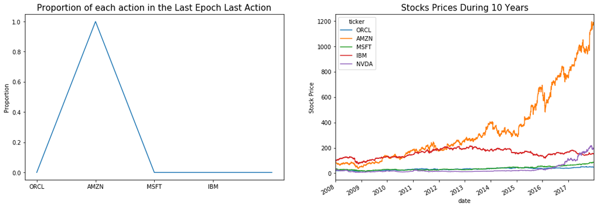

```python
ticks = ['ORCL', 'AMZN', 'MSFT', 'IBM', 'NVDA']
fig, axes = plt.subplots(nrows=1, ncols=2, figsize=(18, 6))
ax = axes[0]
ax.plot(np.mean(cnn_action[-1, :, :], 0))
ax.set_xticks(np.arange(0, 4))
ax.set_xticklabels(ticks, rotation=0)
ax.set_ylabel("Proportion")
ax.set_title("Proportion of each action in the Last Epoch Last Action", fontsize=15)

ax=axes[1]
price[ticks].plot(ax=axes[1])
ax.set_ylabel("Stock Price")
ax.set_title("Stocks Prices During 10 Years", fontsize=15);
```

> Finally, Amazon's proportion that the agent holds tend to be the largest, which obeys with the truth that Amazon's stock is booming all the time to the peak.

### 3.6 Agent Evaluation

Firstly, learning rate is checked for cases to find out the good range of learning rate for this problem. Then the essay tests the influence of the number of days the agent is hired, which is the time we keep the investment. Lastly, the essay testify the number of stocks to confirm the practicality of the agent.

```
CNN lr=0.1 method works now...
No.1 Epoch: Train: 10118.07 ; Test: 10238.59
CNN lr=0.01 method works now...
No.1 Epoch: Train: 10113.95 ; Test: 10288.65
CNN lr=0.001 method works now...
No.1 Epoch: Train: 10105.54 ; Test: 10280.19
CNN lr=0.0001 method works now...
No.1 Epoch: Train: 10120.51 ; Test: 10297.30
CNN lr=0.00001 method works now...
No.1 Epoch: Train: 10113.34 ; Test: 10312.47
CNN step=5 method works now...
No.1 Epoch: Train: 10028.81 ; Test: 10038.78
CNN step=10 method works now...
No.1 Epoch: Train: 10049.50 ; Test: 10103.14
CNN step=20 method works now...
No.1 Epoch: Train: 10113.47 ; Test: 10271.75
CNN step=50 method works now...
No.1 Epoch: Train: 10316.58 ; Test: 10853.71
CNN step=100 method works now...
No.1 Epoch: Train: 10619.44 ; Test: 11733.50
CNN No.Stocks=2 method works now...
No.1 Epoch: Train: 10116.32 ; Test: 10282.68
CNN No.Stocks=4 method works now...
No.1 Epoch: Train: 10117.69 ; Test: 10263.88
CNN No.Stocks=6 method works now...
No.1 Epoch: Train: 10117.52 ; Test: 10292.64
CNN No.Stocks=8 method works now...
No.1 Epoch: Train: 10112.96 ; Test: 10302.63
CNN No.Stocks=10 method works now...
No.1 Epoch: Train: 10112.17 ; Test: 10295.26
```

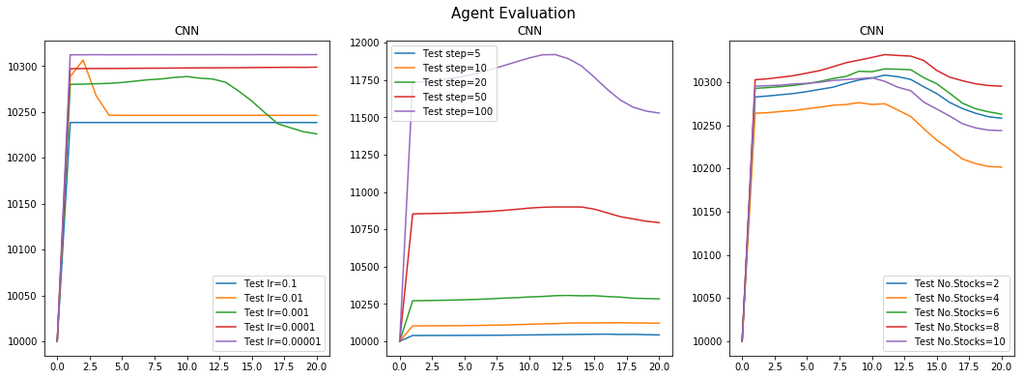

```python
if __name__ == "__main__":
    values = logreturn[['ORCL', 'AMZN', 'MSFT', 'IBM', 'NVDA']].values
    flag = "CNN"

    epochs = 20
    learning_rate = 0.001
    num_batches_train = 1500
    num_batches_test = 200
    num_stocks = values.shape[1]

    train_data = values[:2000]
    test_data = values[2000:]

    step = 20 # approxmiate trading days (must > 1)
    lag = 10 # 10 days lag

    # float
    cost = 1.0 # cost for one stock change
    initial_invest = 10000.0

    fig, axes = plt.subplots(nrows=1, ncols=3, figsize=(18, 6))

    learning_rate = 0.1; runAgent(axes[0], " lr=0.1", False)
    learning_rate = 0.01; runAgent(axes[0], " lr=0.01", False)
    learning_rate = 0.001; runAgent(axes[0], " lr=0.001", False)
    learning_rate = 0.0001; runAgent(axes[0], " lr=0.0001", False)
    learning_rate = 0.00001; runAgent(axes[0], " lr=0.00001", False)

    learning_rate = 0.001
    step = 5; runAgent(axes[1], " step=5", False)
    step = 10; runAgent(axes[1], " step=10", False)
    step = 20; runAgent(axes[1], " step=20", False)
    step = 50; runAgent(axes[1], " step=50", False)
    step = 100; runAgent(axes[1], " step=100", False)

    step = 20
    test_ticks = ['ORCL', 'MSFT', 'IBM', 'NVDA', "GOOGL", "UPS", "JPM", "MO", "AAPL", "CAT"]
    values = logreturn[test_ticks[:2]].values; runAgent(axes[2], " No.Stocks=2", False)
    values = logreturn[test_ticks[:4]].values; runAgent(axes[2], " No.Stocks=4", False)
    values = logreturn[test_ticks[:6]].values; runAgent(axes[2], " No.Stocks=6", False)
    values = logreturn[test_ticks[:8]].values; runAgent(axes[2], " No.Stocks=8", False)
    values = logreturn[test_ticks].values; runAgent(axes[2], " No.Stocks=10", False)

    fig.suptitle("Agent Evaluation", fontsize=15, y=0.96)
```

> The graphs compare the final return corresponding to the training times, with different hyper-parameters. Hopefully all of them are robust to make profits for us.

> It is worth noticing that some returns tends to decline after long time training, which might mean they are overfitting. For example, the violet in the midlle (step=100) has too many variables, which, as bias-variance tradeoff, makes the model too variance.

From the sensitivity analysis of learning rate above in the first graph, we can see learning rate will influence the work a bit. Its decrease evidently increases the return, and does not spend much longer time to converge. The shorter path will lead to global optimization easily. And it can be seen that larger learning rate tends to give unstable results which may lead to leave optimization occasionally.

For the step we hire an agent, the longer takes more money with no doubts, and the proportions among them are quite well, although the longer time period may takes more uncertainty, which means the return starts to fluctuate with steps going larger.

Overall, the main tendency of the agent return is never changed, in which case we can conclude that this DDRN agent is robust and valuable.

## 4. Deep Q Network (DQN)

DQN is famous for games where states, actions and rewards are all significant and clear and it is easier to learn Q values in **Q learning**. For the purpose of research, the essay attempts to utilize this model to build a trading agent, so as to test whether this model in stock market is as brilliant as in the video games.

The essay hereby introduces DQN as an agent-maker algorithm. Here it takes number of batches, number of dates (as lag days), number of stocks and other hyper parameters. And it will stores a deep learning model (the essay uses CNN here) to calculate the Q value of each action, for corresponding states. On the other words, DQN inputs the state (the prices of the stocks today and before) to DNN to get the Q values of every action. In algorithm, the off-policy rule makes value of the action decides the next action. But after some time, the state-reward-action sets during this time will be re-predict by the DNN, and the new values will be added to the old action value. This new-old value pair will be used to train the DNN again. This is the **Experience Replay**.

In conclusion, the difference between DQN and previous DDRN is the **learning target**. DQN learns the Q values, while DDRN learns to predict the stocks directly.

### 4.1 Agent Deployment

The essay takes the algorithm from *Human-level control through deep reinforcement learning* (Mnih et al., 2015) as below. For the sake of learning, I write it by keras API here to just save the model time. The experience replay algorithm is also showed. The memoryD stores the state-actoin-reward pairs to update the DNN.

[figure not shown]

```python
class DQNAgent:
    def __init__(self, num_batches, num_dates, num_stocks, learning_rate, model_name=None, testing=False):
        self.num_batches = num_batches
        self.state_size = num_dates
        self.action_size = num_stocks
        self.testing = testing
        self.learning_rate = learning_rate

        self.gamma = 0.9
        self.epsilon = 0.95

        self.memoryD = []

        self.model = load_model(model_name) if testing else self._model()

    def _model(self):
        model = Sequential()
        model.add(keras.layers.Conv2D(12, (5, 5), padding="same",
                                      input_shape=(self.state_size, self.action_size, 1), activation="relu"))

        model.add(keras.layers.MaxPooling2D(pool_size=(2, 2), strides=2, padding='SAME'))
        model.add(keras.layers.Dropout(0.25))

        model.add(keras.layers.Conv2D(24, (5, 5), padding="same",
                                      input_shape=(math.ceil(self.state_size / 2), math.ceil(self.action_size / 2), 1), activation="relu"))

        model.add(keras.layers.MaxPooling2D(pool_size=(2, 2), strides=2, padding='SAME'))
        model.add(keras.layers.Dropout(0.25))

        model.add(keras.layers.Flatten())
        model.add(keras.layers.Dense(1024, activation="relu"))
        model.add(keras.layers.Dropout(0.2))

        model.add(Dense(self.action_size * 2 + 1, activation="linear"))
        model.compile(loss="mse", optimizer=Adam(lr=self.learning_rate))

        return model

    def act(self, state):
        if not self.testing and random.random() - self.epsilon > 0:
            return np.argmax([np.random.dirichlet(np.ones(self.action_size)) for i in range(self.num_batches)], axis=1)
        else:
            return np.argmax(self.model.predict(state), axis=1)

    def expReplay(self):
        for state, action, reward, state_p, done in self.memoryD:
            y = reward + self.gamma * np.max(self.model.predict(state_p)) * (not done)
            y_all = self.model.predict(state)
            y_all[:, action] = y
            self.model.fit(state, y_all, verbose=0)
        self.memoryD.pop(0)
```

### 4.2 Trading Policy

States and actions are easy to represent since price and return are determined. But actions can vary a lot. Since Q value table cannot be too continuous in terms of actions though DNN can ease a little. I hereby give $(numberofstocks * 2 + 1)$ as the action size. The first $numberofstocks$ actions represent investing this stocks, the second $numberofstocks$ actions represent withdrawing investment, and the last one action represents doing nothing.

```python
def runDQN():
    tf.reset_default_graph()
    agent = DQNAgent(num_batches_train, lag+1, num_stocks, learning_rate)
    final_train = []
    for epoch in range(1, epochs+1):
        batches = build_batch(train_data, step, lag, num_batches_train)
        invest_all = initial_invest * np.ones(num_batches_train)
        pre_invest = np.array([[initial_invest / num_stocks for i in range(num_stocks)] for _ in range(num_batches_train)])
        for i in range(step-1):
            state = batches[:, i:i+lag+1, :].reshape(num_batches_train, lag+1, num_stocks, 1)
            action = agent.act(state)
            state_p = batches[:, i+1:i+lag+2, :].reshape(num_batches_train, lag+1, num_stocks, 1)

            for batch in range(num_batches_train): # policy for each batch
                one_invest = invest_all[batch] * 0.2
                if action[batch] < num_stocks:
                    pre_invest[batch] = [invest - one_invest / num_stocks * (action[batch]!=stock) + one_invest * (action[batch]==stock) \
                                         for stock, invest in enumerate(pre_invest[batch])]
                elif num_stocks <= action[batch] < num_stocks * 2:
                    pre_invest[batch] = [invest + one_invest / num_stocks * (action[batch]!=stock) - one_invest * (action[batch]==stock) \
                                         for stock, invest in enumerate(pre_invest[batch])]

            reward = np.sum((np.exp(state_p[:, -1, :, :].squeeze()) - 1) * pre_invest, axis=1) - cost * invest_all * 0.2
            invest_all = invest_all + reward

            done = (i == (step-2))
            agent.memoryD.append((state, action, reward, state_p, done))
            state = state_p

            if len(agent.memoryD) >= 10:
                agent.expReplay()

        agent.memoryD = []
        final_train.append(np.mean(invest_all))

        print("No.%d Epoch: Train: %0.2f"%(epoch, final_train[-1]))
        if epoch % 10 == 0:
            model_name = "model" + str(epoch)
            agent.model.save(model_name)
```

### 4.3 Discuss

The return will imporve after long time training, but too slowly, which has been testified, but cannot be showed here due to the composition. The results for DQN agent are not very satisfactory, this is actually a drawback of DQN that it cannot monitor the time series very well, since time series data has many possible rules, i.e. the Q-values of the action is hard to monitor automatically with this Experience Replay （Zheng et al., 2016; Zheng et al., 2014; Längkvis et al., 2014):

- Firstly, the model needs the overall understanding towards the actions. For example, video games do limited actions that can be calculated for each Q values. However, it is not easy as well to define the actions in stock market. Buying or selling has differing forms, with the amount, the time, the exchange and so on to concern. So if the action policy is not stable or practical, the agent will unlikely lead to global optimization. E.g. if we use DQN to play *Mario*, only telling the agent that player can jump, without saying one can also jump high and jump low. The agent will learn, but it is too slow.
- Secondly, unlike games can be played again and again to train by themselves when restarting the games. The stock market data is actually limited and the amount is not big at all to excute the long-time training. Thus, the environment for agent to learn is not quite enough.
- Lastly, a game always have a rule since it is made by people, but stock market rule is even harder to confirm whether there is a rule and whether this rule is useful next time.

```python
if __name__ == "__main__":
    values = logreturn[['AAPL', 'GOOGL']].values

    epochs = 9
    learning_rate = 0.01
    num_batches_train = 1500
    num_batches_test = 200
    num_stocks = values.shape[1]

    train_data = values[:2000]
    test_data = values[2000:]

    step = 30 # approxmiate trading days a year
    lag = 10 # 10 days lag

    # float
    cost = 0.005 # cost for one stock change
    initial_invest = 10000.0

    runDQN()
```

```
No.1 Epoch: Train: 10065.61
No.2 Epoch: Train: 10234.87
No.3 Epoch: Train: 10161.63
No.4 Epoch: Train: 10071.39
No.5 Epoch: Train: 10113.84
No.6 Epoch: Train: 10055.56
No.7 Epoch: Train: 10021.56
No.8 Epoch: Train: 10255.40
No.9 Epoch: Train: 10221.27
```

> The model training is very computational consuming, the essay only shows several Epochs to show the main intuitives, since it cannot give good result, as explained previous.

## 5. Conclusion

The essay makes two different kinds of agents, i.e. DDRN Agent and DQN Agent. I hereby compare the two for further understanding of them.

DDRN uses a direct reinforcement network as the foundation, while DQN uses Q learning reinforcement. The former makes sequential deep neural network, with each state holds a deep neural network to be responsible for prediction. The latter makes the sequential network as well, but uses the neural network to acquire Q value for each state and action.

For DDRN, my action is the distribution of the stocks by investment. For DQN, my action is to buy or to sell the stocks. The former is more flexible and tend to find the optimization since its large coverage. The latter highly relies on the action we can choose.

For DDRN, the essay provides a good agent to help make over 14% within 100 trading days, and even approaching the best policy. At the same time, the model itself is proven to be robust, overall and practically to many situations. As for DQN, the essay provides a solution creatively and opens a good mind towards trading with constraints.

The work provides good results in allocation trading or portfolio formation. Further focus on action-trading and how to provide specific actions towards different issues is in need for further research.

## 6. Reference

Choi, James J., et al. "Reinforcement learning and savings behavior." The Journal of finance 64.6 (2009): 2515-2534.

Chung, Junyoung, et al. "Empirical evaluation of gated recurrent neural networks on sequence modeling." arXiv preprint arXiv:1412.3555 (2014).

Deng Y , Bao F , Kong Y , et al. Deep Direct Reinforcement Learning for Financial Signal Representation and Trading[J]. IEEE Transactions on Neural Networks and Learning Systems, 2016, 28(3):1-12.

Fischer, Thomas, and Christopher Krauss. "Deep learning with long short-term memory networks for financial market predictions." European Journal of Operational Research 270.2 (2018): 654-669.

Gers, Felix A., Jürgen Schmidhuber, and Fred Cummins. "Learning to forget: Continual prediction with LSTM." (1999): 850-855.

Heaton, J. B., N. G. Polson, and Jan Hendrik Witte. "Deep learning for finance: deep portfolios." Applied Stochastic Models in Business and Industry 33.1 (2017): 3-12.

Heaton, Jeff. Ian Goodfellow, Yoshua Bengio, and Aaron Courville: Deep learning[J]. Genetic Programming and Evolvable Machines, 2017.

Hochreiter, Sepp, and Jürgen Schmidhuber. "Long short-term memory." Neural computation 9.8 (1997): 1735-1780.

Jiang Z , Xu D , Liang J . A Deep Reinforcement Learning Framework for the Financial Portfolio Management Problem[J]. Papers, 2017.

Jondeau, Eric, and Michael Rockinger. "Optimal portfolio allocation under higher moments." European Financial Management 12.1 (2006): 29-55.

Keon. Deep Q-Learning with Keras and Gym[EB/OL]. 2018. Retrieved from https://keon.io/deep-q-learning/.

Kimoto, Takashi, et al. "Stock market prediction system with modular neural networks." 1990 IJCNN international joint conference on neural networks. IEEE, 1990.

Krizhevsky, Alex, Ilya Sutskever, and Geoffrey E. Hinton. "Imagenet classification with deep convolutional neural networks." Advances in neural information processing systems. 2012.

Längkvist, Martin, Lars Karlsson, and Amy Loutfi. "A review of unsupervised feature learning and deep learning for time-series modeling." Pattern Recognition Letters 42 (2014): 11-24.

Lin, Min, Qiang Chen, and Shuicheng Yan. "Network in network." arXiv preprint arXiv:1312.4400 (2013).

llSourcell. Stock Price Prediction using Reinforcement Learning[EB/OL]. 2017. Retrieved from https://github.com/llSourcell/Machine_Learning_Journey.

Mnih, Volodymyr, et al. "Human-level control through deep reinforcement learning." Nature 518.7540 (2015): 529.

Saad W . Comparative study of stock trend prediction using time delay, recurrent and probabilistic neural network[J]. IEEE Transactions on Neural Networks, 1998, 9(6):1456-70.

Schöneburg, Eberhard. "Stock price prediction using neural networks: A project report." Neurocomputing 2.1 (1990): 17-27. Sutton R S , Barto A G. Reinforcement Learning: An Introduction[J]. 1998.

Zhan. R, He T, Li Y. Deep Reinforcement Learning in Portfolio Management[EB/OL].2018. Retrieved from https://ruohanzhan.github.io/research.html

Zhang, Yudong, and Lenan Wu. "Stock market prediction of S&P 500 via combination of improved BCO approach and BP neural network." Expert systems with applications 36.5 (2009): 8849-8854.

Zheng, Yi, et al. "Exploiting multi-channels deep convolutional neural networks for multivariate time series classification." Frontiers of Computer Science 10.1 (2016): 96-112.

Zheng, Yi, et al. "Time series classification using multi-channels deep convolutional neural networks." International Conference on Web-Age Information Management. Springer, Cham, 2014.